# A Clever Title About Museum Grants

### Where did all that funding go?

The 628 grants were awarded to 254 different museums. Of those 254, 44% received one grant and the remaining 56% received multiple grants. The American Museum of Natural History in New York tops the list both in terms of number of grants received (12) and the total funding received ($3,411,368).

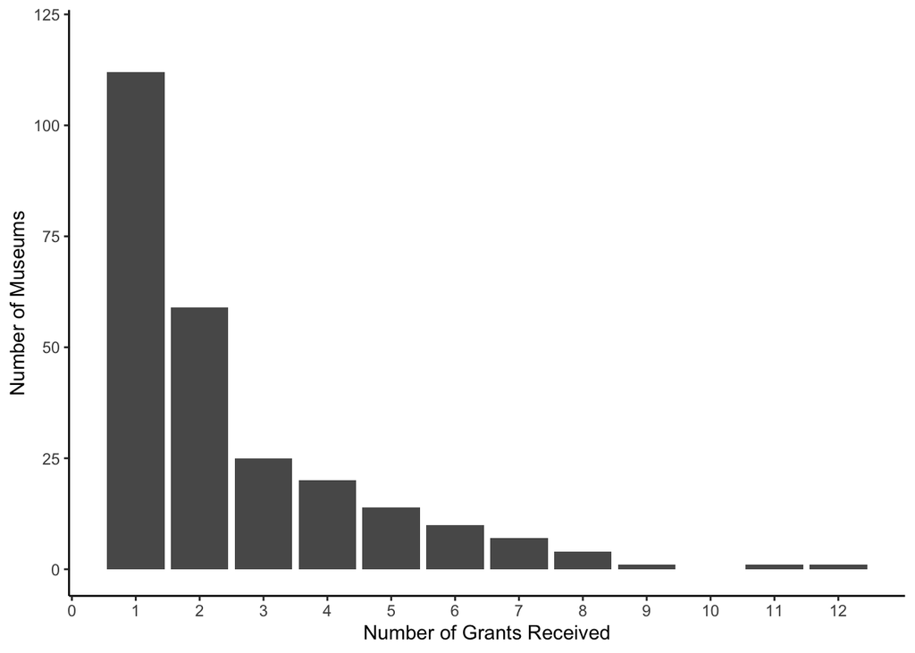

At the state level, museums in New York, Illinois, and California received the most funding. There weren’t any museums in South Dakota or Oklahoma that were awarded grants from the IMLS.

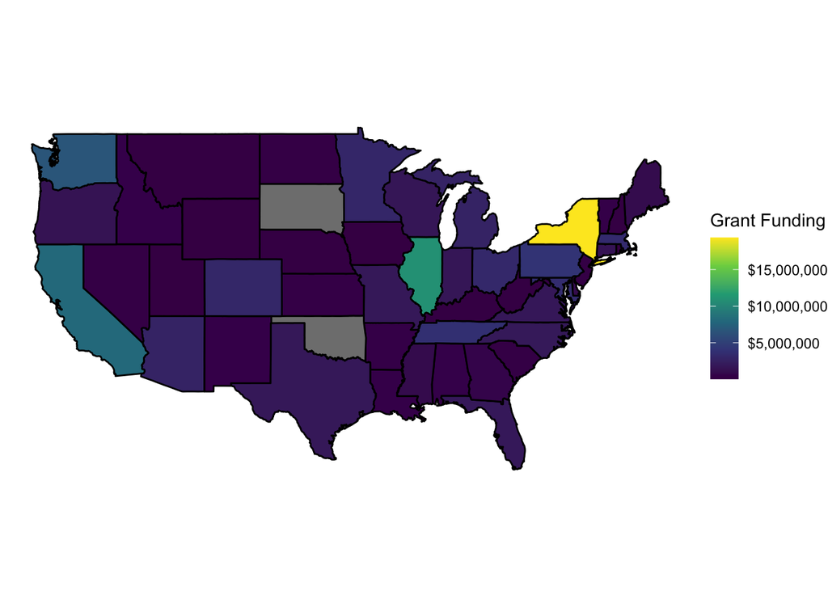

There’s a clear leader when comparing funding by museum discipline. Nearly $30 million was awarded to art museums, almost 50% more than the runner up, children’s museums. Botanical gardens, zoos/aquariums, and science museums received similar amounts. History museums received the least amount of funds with $6,201,416.

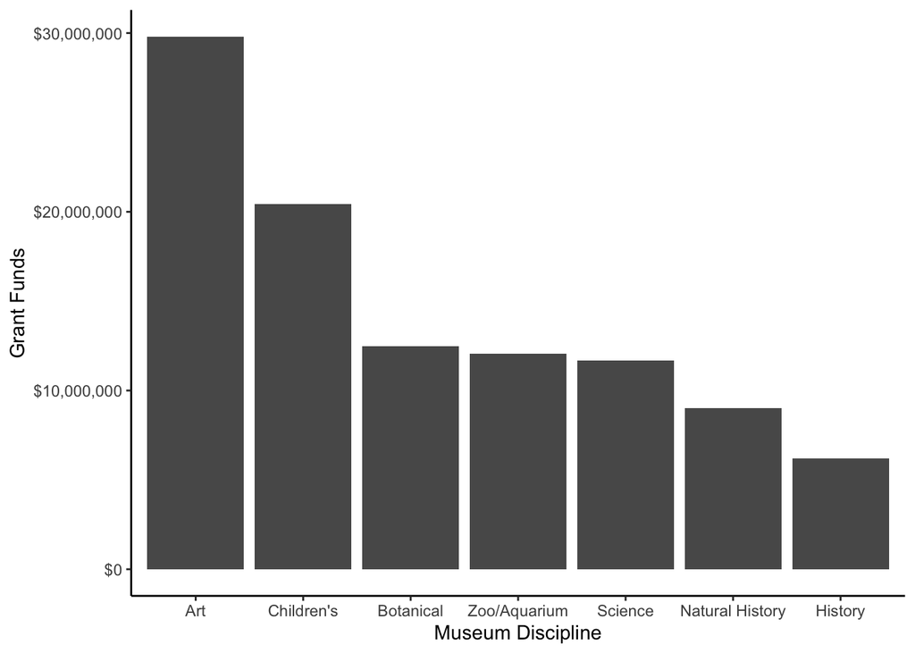

### More funding went to museums with higher income

I was curious to see how the grants are distributed relative to income reported by the museums. Surprisingly, more funding went to museums with higher income levels. This contradicted my assumption that grants would go to institutions that needed funding, and that museums with higher income need less funding because they have the resources to support their initiatives.

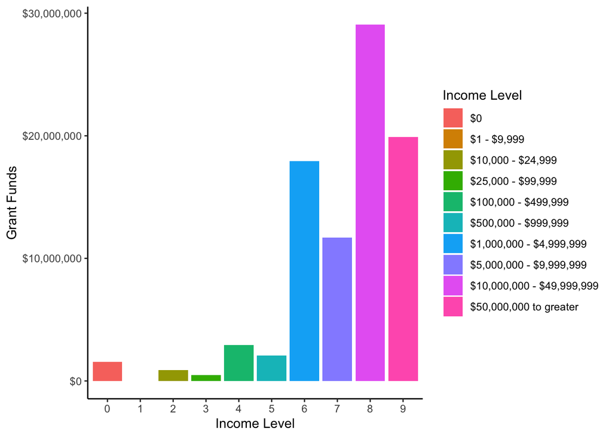

*Note - income data wasn’t available for 15% of the museums and they aren’t included in the chart above.*

### But how does this compare to income levels across *all* museums?

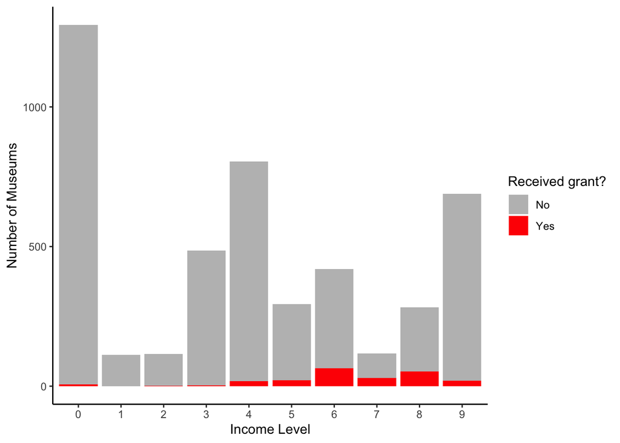

*Note - income data wasn’t available for 35% of the museums that did not receive a grant and they aren’t included in the chart above.*

### Most grant programs require matching funds

Let’s look at how these grants are actually awarded. The IMLS has multiple grant programs with various eligibility criteria, funding amounts, and cost share requirements. In this data, the top four programs by funding awarded **represent 95% of the total funding** over the last 10 years. Of those, the top three require that the museum, “provide funds from non-federal sources in an amount that is equal to or greater than” the amount requested in the grant application. For example, if a museum applies for a $100,000 grant through the *Museums for America* program they must match that amount through other (non-federal) means.

| Rank | Program | Total Funds | Number of Grants | Requires Matching Funds? |
| --- | --- | --- | --- | --- |
| 1 | Museums for America | $70,578,719 | 465 | Yes |
| 2 | National Leadership Grants - Museums | $16,292,260 | 37 | Yes |
| 3 | Museums Empowered | $7,966,050 | 53 | Yes |
| 4 | Inspire! Grants for Small Museums | $2,141,872 | 46 | No |

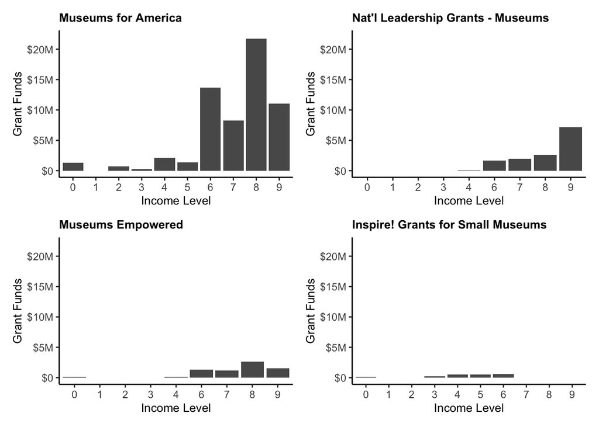

### The burden of matching funds

```r
# test with Museums for America only to start
# median grant value through Museums for America
data %>%
  filter(program == "Museums for America") %>%
  summarize(median_grant = median(funds))
```

```
## # A tibble: 1 × 1
##   median_grant
##          <dbl>
## 1       149967
```

```r
# create plot of income codes
income_codes <- tibble(
  code = as.factor(c(0:9)),
  low = c(0, 1, 10000, 25000, 100000, 500000, 1000000, 5000000, 10000000, 50000000),
  high = c(0, 9999, 24999, 99999, 499999, 999999, 4999999, 9999999, 49999999, 50000000)
) %>%
  mutate(mid = ((high - low)/2) + low,
         median_grant = 149967,
         ratio = mid/median_grant,
         percent = (median_grant/mid) * 100
         )

income_codes
```

```
## # A tibble: 10 × 7
##    code       low     high       mid median_grant    ratio  percent
##    <fct>    <dbl>    <dbl>     <dbl>        <dbl>    <dbl>    <dbl>
##  1 0            0        0        0        149967   0       Inf
##  2 1            1     9999     5000        149967   0.0333 2999.
##  3 2        10000    24999    17500.       149967   0.117   857.
##  4 3        25000    99999    62500.       149967   0.417   240.
##  5 4       100000   499999   300000.       149967   2.00     50.0
##  6 5       500000   999999   750000.       149967   5.00     20.0
##  7 6      1000000  4999999  3000000.       149967  20.0       5.00
##  8 7      5000000  9999999  7500000.       149967  50.0       2.00
##  9 8     10000000 49999999 30000000.       149967 200.        0.500
## 10 9     50000000 50000000 50000000        149967 333.        0.300
```

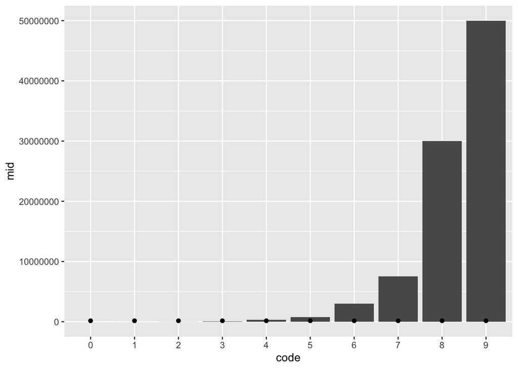

```r
income_codes %>%
  ggplot(aes(x = code,
             y = mid
             )
         ) +
  geom_col() +
  geom_point(aes(x = code,
                 y = median_grant
                 )
             )
```

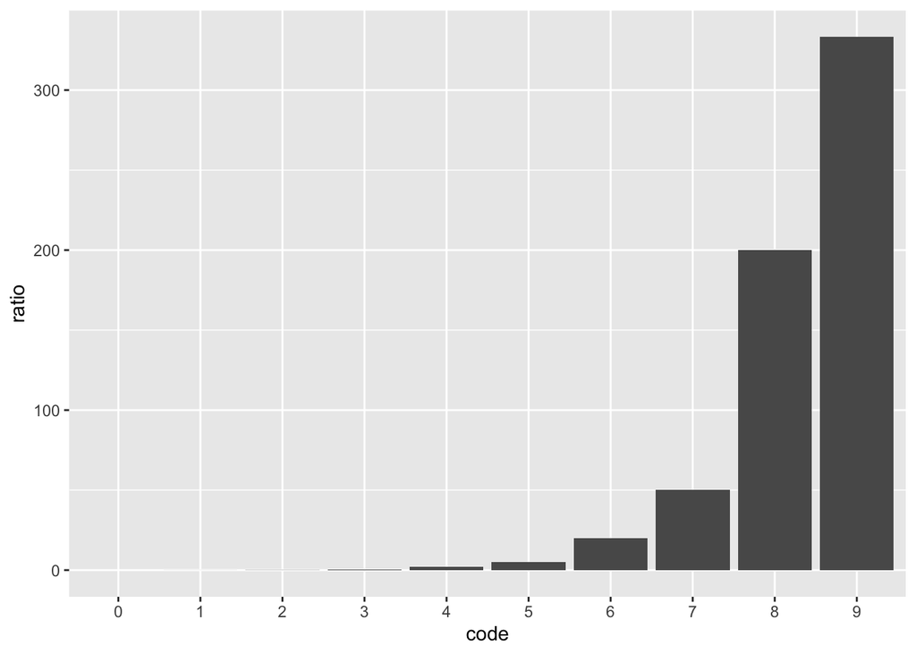

```r
# ration of income (mid) to median grant
income_codes %>%
  ggplot(aes(x = code,
             y = ratio
             )
         ) +
  geom_col()
```

### Call to action

- Access to museums improve outcomes
- IMLS should direct more funding to areas that need it
- People can donate to the least likely museums

### Footnotes

1. I don’t know why the institutions did not receive a grant.
2. INCOMECD15 used as benchmark for income even though it could be different before or after.
3. Institutions may have received a grant in a different year than when their INCOMECD15 year
4. The [application information](https://imls.gov/grants/available/inspire-grants-small-museums) for this program explains that it is designed to support small museums, but it’s not clear how “small” is defined. If there is a correlation between size and income level, then museums with high income levels may not be eligible for this program. That could be one explanation for the distribution above. Unfortunately, the IMLS data doesn’t contain information regarding size.

### Methodology

The IMLS also makes available data regarding the grants they award to these institutions for various initiatives.

### To Do

- CSS to set width of html output?
- Link to GitHub repository
- AK and HI in map
- Color scale in map
- Account for number of museums in state, discipline?
- colors for funds by discipline
- rename income Level or use a legend early on?
- link to footnotes
- bold key text
- center charts
- smart brevity?